# Assignment 1

I would choose 3 factors in the final model, despite the failed chi-squared test because 3 factors gives communality for all factor loadings, only variable Info8 cross-loads, and the total explained variance is higher than that of a 2 factor model, and the grouping of variables is logical.

```r
# With all 10 Info variables, the Chi-squared test suggests that no number of factors (1 to 6) are sufficent.
# If we drop Info5, the Chi-squared test suggests that 5 factors are sufficent, but we need to make sure that makes sense when looking at the factor loadings.
NrFactors <- 1:5
pvals <- rep(NA,times=length(NrFactors))
for(k in NrFactors){
  # Estimate k-factor model:
  Estimation <- factanal(no_outliers[,c(8:11,13:17)],factors=k,rotation="varimax")
  pvals[k] <- Estimation$PVAL
}

cbind(NrFactors,pvals)
```

```
     NrFactors         pvals
[1,]         1 1.882397e-230
[2,]         2  1.294526e-74
[3,]         3  1.208741e-18
[4,]         4  7.868214e-07
[5,]         5  1.474382e-01
```

Each factor should have a high loading on several variables (communality) and each variable should load high on one factor loading and variable groupings should make sense.

```r
# Factor 5 and 4 don't have high communality
print("k=5")
```

```
[1] "k=5"
```

```r
EFA.kfactors <- factanal(no_outliers[,c(8:11,13:17)], factors=5, rotation="varimax")
EFA.kfactors$loadings
```

```
Loadings:
       Factor1 Factor2 Factor3 Factor4 Factor5
Info1  0.923   0.252   0.212   0.183
Info2  0.518   0.142   0.379   0.275   0.192
Info3  0.630   0.248   0.360   0.130   0.295
Info4  0.506   0.199   0.368   0.274   0.490
Info6  0.246   0.872   0.170           0.105
Info7  0.133   0.710   0.168   0.227
Info8  0.396   0.274   0.678   0.245   0.165
Info9  0.390   0.350   0.551   0.361
Info10 0.210   0.235   0.229   0.795   0.103

               Factor1 Factor2 Factor3 Factor4 Factor5
SS loadings      2.206   1.702   1.327   1.083   0.423
Proportion Var   0.245   0.189   0.147   0.120   0.047
Cumulative Var   0.245   0.434   0.582   0.702   0.749
```

```r
# Factor 4 and 3 don't have high communality
print("k=4")
```

```
[1] "k=4"
```

```r
EFA.kfactors <- factanal(no_outliers[,c(8:11,13:17)], factors=4, rotation="varimax")
EFA.kfactors$loadings
```

```
Loadings:
       Factor1 Factor2 Factor3 Factor4
Info1  0.804   0.267   0.176   0.152
Info2  0.636   0.138   0.297   0.223
Info3  0.784   0.243   0.119   0.213
Info4  0.660   0.209   0.296   0.254
Info6  0.290   0.865           0.132
Info7  0.163   0.716   0.241   0.133
Info8  0.491   0.254   0.248   0.792
Info9  0.506   0.351   0.401   0.365
Info10 0.287   0.236   0.746   0.164

               Factor1 Factor2 Factor3 Factor4
SS loadings      2.791   1.696   1.067   1.006
Proportion Var   0.310   0.188   0.119   0.112
Cumulative Var   0.310   0.499   0.617   0.729
```

```r
# All factors have high communality
# Info 8 cross-loads
# Explained variance is low
print("k=3")
```

```
[1] "k=3"
```

```r
EFA.kfactors <- factanal(no_outliers[,c(8:11,13:17)], factors=3, rotation="varimax")
EFA.kfactors$loadings
```

```
Loadings:
       Factor1 Factor2 Factor3
Info1  0.770   0.268   0.281
Info2  0.603   0.136   0.421
Info3  0.804   0.241   0.233
Info4  0.650   0.207   0.413
Info6  0.285   0.869   0.170
Info7  0.151   0.709   0.278
Info8  0.541   0.275   0.568
Info9  0.457   0.340   0.644
Info10 0.276   0.242   0.590

               Factor1 Factor2 Factor3
SS loadings      2.706   1.699   1.673
Proportion Var   0.301   0.189   0.186
Cumulative Var   0.301   0.489   0.675
```

```r
# Both factors have high communality
print("k=2")
```

```
[1] "k=2"
```

```r
EFA.kfactors <- factanal(no_outliers[,c(8:11,13:17)], factors=2, rotation="varimax")
EFA.kfactors$loadings
```

```
Loadings:
       Factor1 Factor2
Info1  0.795   0.257
Info2  0.731   0.173
Info3  0.785   0.240
Info4  0.771   0.230
Info6  0.365   0.710
Info7  0.191   0.894
Info8  0.743   0.324
Info9  0.703   0.393
Info10 0.511   0.351

               Factor1 Factor2
SS loadings      3.852   1.891
Proportion Var   0.428   0.210
Cumulative Var   0.428   0.638
```

4. Report the set of included variables, the estimated uniquenesses and factor loadings of your final factor model. Continue the next questions with the model you prefer.

```r
EFA.kfactors <- factanal(no_outliers[,c(8:11,13:17)], factors=3, rotation="varimax")
EFA.kfactors
```

```
Call:
factanal(x = no_outliers[, c(8:11, 13:17)], factors = 3, rotation = "varimax")

Uniquenesses:
 Info1  Info2  Info3  Info4  Info6  Info7  Info8  Info9 Info10
 0.257  0.441  0.242  0.364  0.135  0.397  0.310  0.260  0.517

Loadings:
       Factor1 Factor2 Factor3
Info1  0.770   0.268   0.281
Info2  0.603   0.136   0.421
Info3  0.804   0.241   0.233
Info4  0.650   0.207   0.413
Info6  0.285   0.869   0.170
Info7  0.151   0.709   0.278
Info8  0.541   0.275   0.568
Info9  0.457   0.340   0.644
Info10 0.276   0.242   0.590

               Factor1 Factor2 Factor3
SS loadings      2.706   1.699   1.673
Proportion Var   0.301   0.189   0.186
Cumulative Var   0.301   0.489   0.675

Test of the hypothesis that 3 factors are sufficient.
The chi square statistic is 113.51 on 12 degrees of freedom.
The p-value is 1.21e-18
```

### Question 17

Which names do you suggest for the factors? Motivate the names you have chosen.

```r
f1 <- c(8,9,10,11)
f2 <- c(13, 14)
f3 <- c(15,16,17)
```

3 Factors 1. Info1, Info2, Info 3, Info4: Industry - Suppliers of facilities, equipment, components, software and services - Sources within your firm or enterprise group - Customers or principals - Competitor or other enterprise in your industry sector 2. Info6, Info7: Research - Universities, universities of applied science or other higher education institutions - National or non-profit research institutions 3. Info8, Info9, Info10: Other - Conferences, fairs, exhibitions - Scientific periodicals and specialty publications - Associations and boards

### Question 18

Perform a reliability analysis of each factor. (a) Which criterion do you use? Which of the variables, if any, should be dropped?

```r
# The closer alpha is to 1, the better
# No variables should be dropped from f1, f2, or f3

f1_alpha <- psych::alpha(no_outliers[,f1])
f2_alpha <- psych::alpha(no_outliers[,f2])
f3_alpha <- psych::alpha(no_outliers[,f3])
```

[output not shown]

2. If one or more of the variables should be dropped, redo the scree plot and the estimation of the factor model with the number of factors suggested by the scree plot. Report and motivate all the steps you have taken to arrive at a final factor model. Report the set of included variables, the estimated uniquenesses and factor loadings of your final factor model.

```r
EFA.kfactors <- factanal(no_outliers[,c(8:11,13:17)], factors=3, rotation="varimax")
EFA.kfactors$uniquenesses
```

```
    Info1     Info2     Info3     Info4     Info6     Info7     Info8     Info9    Info10
0.2565277 0.4407167 0.2416481 0.3636290 0.1348691 0.3968228 0.3100146 0.2604292 0.5173420
```

```r
EFA.kfactors$loadings
```

```
Loadings:
       Factor1 Factor2 Factor3
Info1  0.770   0.268   0.281
Info2  0.603   0.136   0.421
Info3  0.804   0.241   0.233
Info4  0.650   0.207   0.413
Info6  0.285   0.869   0.170
Info7  0.151   0.709   0.278
Info8  0.541   0.275   0.568
Info9  0.457   0.340   0.644
Info10 0.276   0.242   0.590

               Factor1 Factor2 Factor3
SS loadings      2.706   1.699   1.673
Proportion Var   0.301   0.189   0.186
Cumulative Var   0.301   0.489   0.675
```

3 Factors 1. Info1, Info2, Info 3, Info4: Industry - Suppliers of facilities, equipment, components, software and services - Sources within your firm or enterprise group - Customers or principals - Competitor or other enterprise in your industry sector 2. Info6, Info7: Research - Universities, universities of applied science or other higher education institutions - National or non-profit research institutions 3. Info8, Info9, Info10: Other - Conferences, fairs, exhibitions - Scientific periodicals and specialty publications - Associations and boards

### Question 19

Perform a validity analysis of your factor model by splitting the sample in two ran- dom partitions and comparing the factor loadings. Report the estimated unique- nesses and factor loadings of the split samples. What do you conclude?

The factor loadings and uniqueness of variables are very similar between partitions 1 and 2. The variable groupings also remain the same between the partition.

```r
Data <- data.frame(no_outliers)
# Identify the number of observations in Data:
N <- dim(Data)[1]
# Create a random index vector:
shuffle.index <- sample(1:N,size=N/2)
# Shuffle the data:
no_outliers.Partition1 <- Data[shuffle.index,]
no_outliers.Partition2 <- Data[-shuffle.index,]
```

```r
EFA.kfactors.1 <- factanal(no_outliers.Partition1[,c(8:11,13:17)], factors=3, rotation="varimax")
EFA.kfactors.2 <- factanal(no_outliers.Partition2[,c(8:11,13:17)], factors=3, rotation="varimax")
EFA.kfactors.1
```

```
Call:
factanal(x = no_outliers.Partition1[, c(8:11, 13:17)], factors = 3,     rotation = "varimax")

Uniquenesses:
 Info1  Info2  Info3  Info4  Info6  Info7  Info8  Info9 Info10
 0.263  0.440  0.238  0.339  0.203  0.331  0.317  0.274  0.489

Loadings:
       Factor1 Factor2 Factor3
Info1  0.774   0.263   0.264
Info2  0.592   0.430   0.156
Info3  0.807   0.233   0.237
Info4  0.654   0.439   0.201
Info6  0.304   0.182   0.819
Info7  0.156   0.274   0.755
Info8  0.540   0.567   0.263
Info9  0.449   0.642   0.335
Info10 0.245   0.632   0.227

               Factor1 Factor2 Factor3
SS loadings      2.699   1.743   1.665
Proportion Var   0.300   0.194   0.185
Cumulative Var   0.300   0.494   0.679

Test of the hypothesis that 3 factors are sufficient.
The chi square statistic is 62.03 on 12 degrees of freedom.
The p-value is 9.59e-09
```

```r
EFA.kfactors.2
```

```
Call:
factanal(x = no_outliers.Partition2[, c(8:11, 13:17)], factors = 3,     rotation = "varimax")

Uniquenesses:
 Info1  Info2  Info3  Info4  Info6  Info7  Info8  Info9 Info10
 0.249  0.440  0.246  0.386  0.103  0.435  0.302  0.247  0.542

Loadings:
       Factor1 Factor2 Factor3
Info1  0.772   0.268   0.289
Info2  0.620   0.109   0.404
Info3  0.803   0.246   0.222
Info4  0.655   0.203   0.379
Info6  0.277   0.892   0.161
Info7  0.148   0.685   0.270
Info8  0.549   0.283   0.563
Info9  0.475   0.344   0.640
Info10 0.316   0.263   0.537

               Factor1 Factor2 Factor3
SS loadings      2.779   1.718   1.553
Proportion Var   0.309   0.191   0.173
Cumulative Var   0.309   0.500   0.672

Test of the hypothesis that 3 factors are sufficient.
The chi square statistic is 65.19 on 12 degrees of freedom.
The p-value is 2.52e-09
```

### Question 20

Report the results of the factor analysis in a table, including all the important metrics.

```r
EFA.3factors <- factanal(no_outliers[,c(8:11,13:17)], factors=3, rotation="varimax", scores="regression")

FactorScores <- data.frame(EFA.3factors$scores)
final.data <- no_outliers[,c(1:7)]
final.data$InfoIndustrySector <- FactorScores$Factor1
final.data$InfoResearchSector <- FactorScores$Factor2
final.data$InfoOther <- FactorScores$Factor3
```

### Question 21

What type of variables are the estimated factors? Choose from nominal scale, ordinal scale, interval scale or ratio scale and explain your answer.

The Info variables are from the ordinal scale because the interpretation of each option can vary from person to person meaning that the difference between the variables is relative. However, the answer options do have a relative order.

### Question 22

For each type of innovation (product, service, manufacturing, logistics and sup- port), check whether firms that have introduced such innovations load higher on each of the factors than firms that have not. Support your answers by plots and by statistical tests. What do you conclude?

There is a significant difference between all Info variables and Innovation variables except for InfoResearchSector and LogisticsInnovation.

```
InfoIndustrySector ProductInnovation p-value 2.410424e-133
```

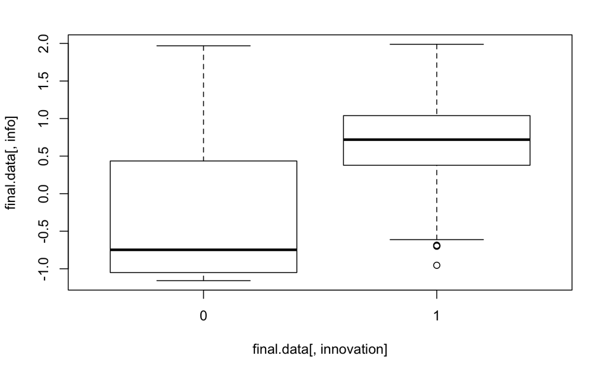

```
InfoIndustrySector ServiceInnovation p-value 5.784002e-40
```

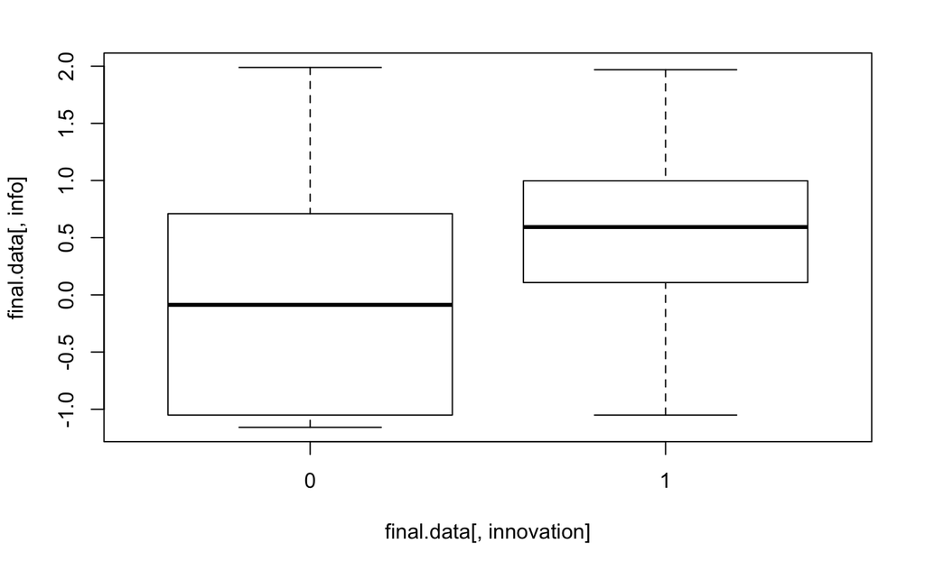

```
InfoIndustrySector ManufacturingInnovation p-value 2.008378e-71
```

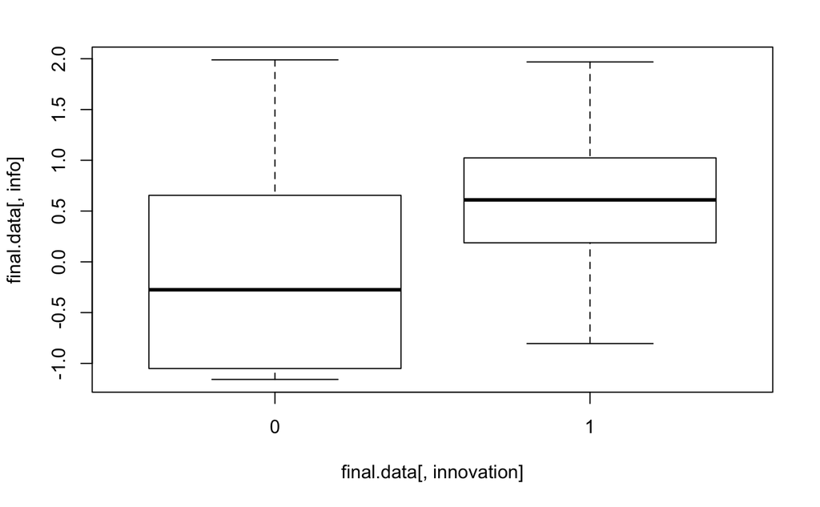

```
InfoIndustrySector LogisticsInnovation p-value 3.848308e-26
```

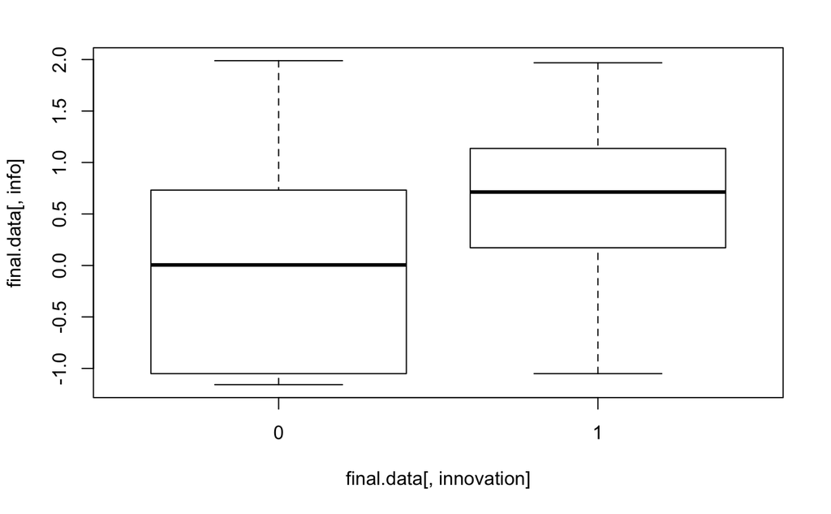

```
InfoResearchSector ProductInnovation p-value 5.561143e-21
```

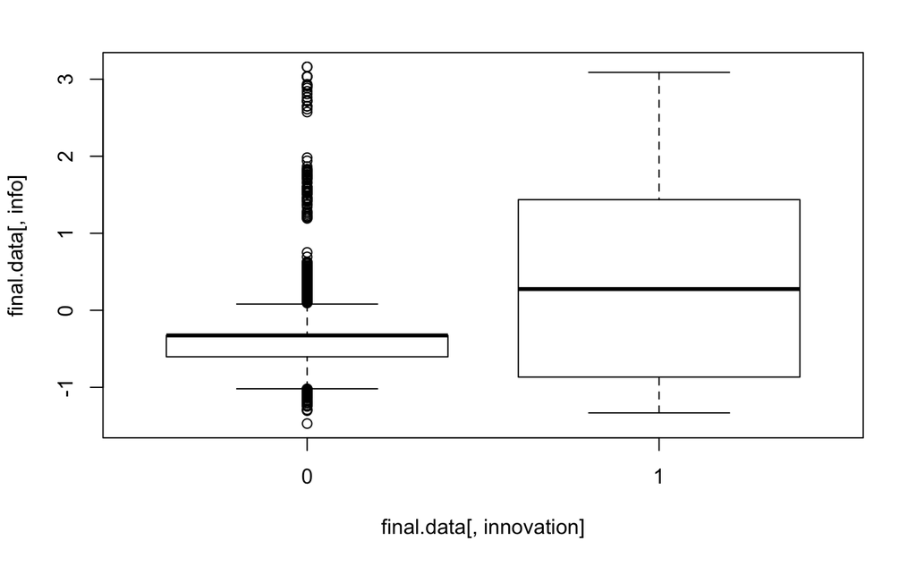

```
InfoResearchSector ServiceInnovation p-value 0.02777071
```

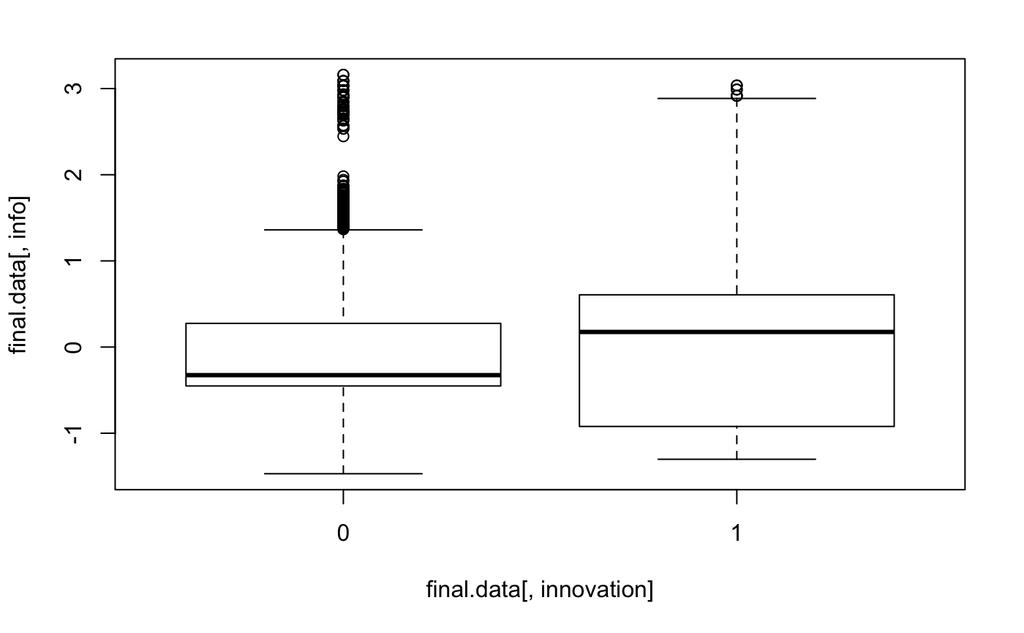

```
InfoResearchSector ManufacturingInnovation p-value 8.145795e-08
```

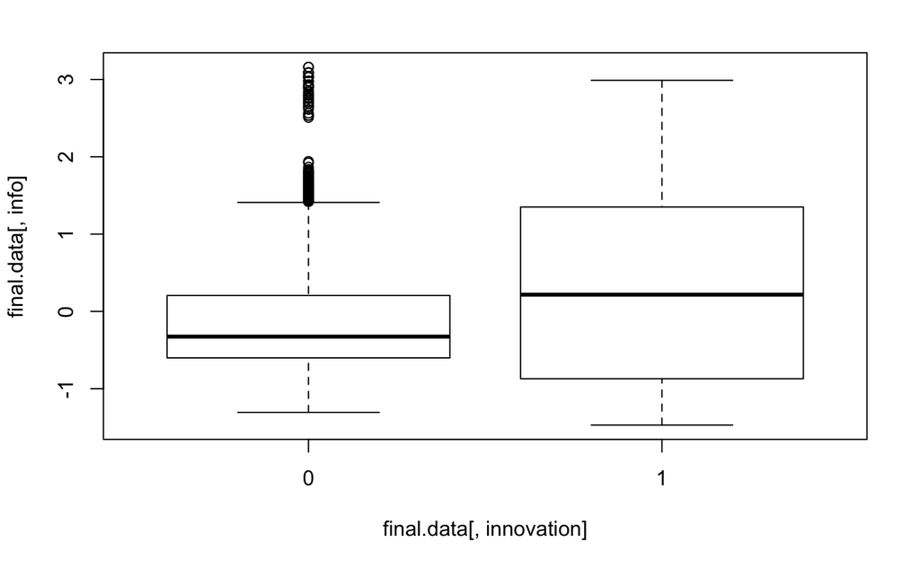

```
InfoResearchSector LogisticsInnovation p-value 0.9895537
```

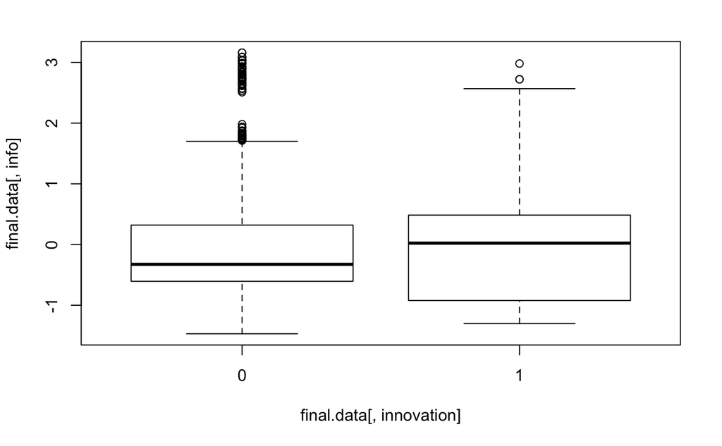

```
InfoOther ProductInnovation p-value 1.158287e-05
```

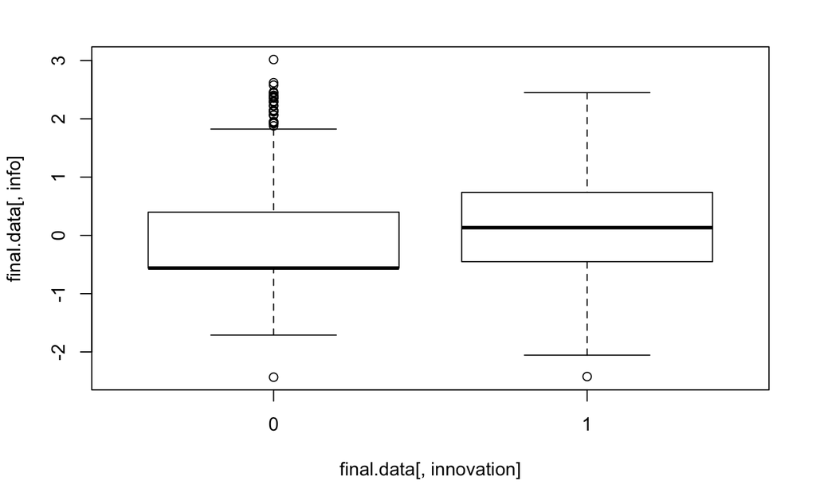

```
InfoOther ServiceInnovation p-value 5.574716e-08
```

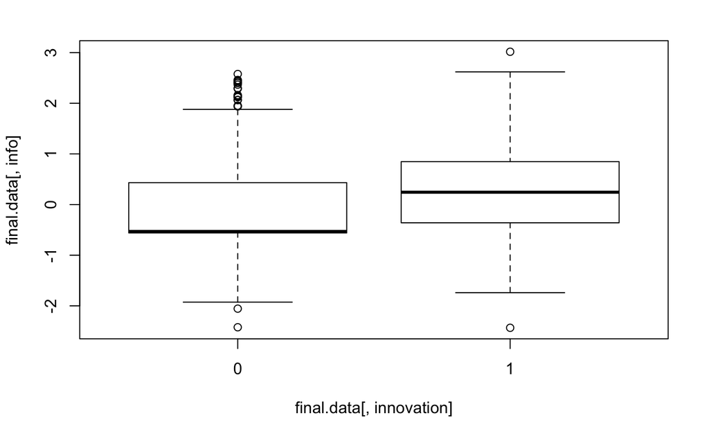

```
InfoOther ManufacturingInnovation p-value 2.832024e-13
```

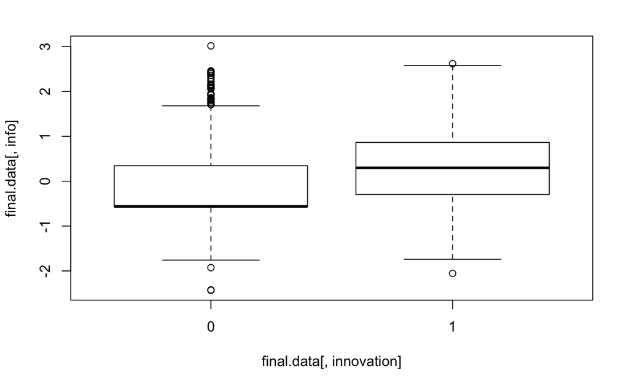

```
InfoOther LogisticsInnovation p-value 6.538343e-05
```

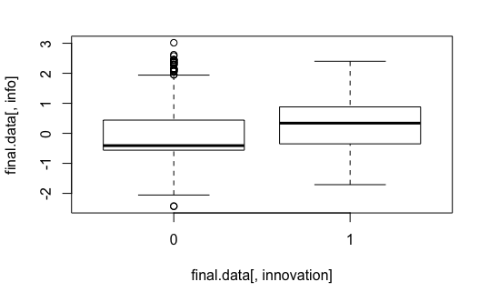

```r
for(info in c("InfoIndustrySector","InfoResearchSector","InfoOther")) {
  for(innovation in c("ProductInnovation","ServiceInnovation","ManufacturingInnovation","LogisticsInnovation")) {
    #hist(final.data[,info], breaks=100, col='red')
    boxplot(final.data[,info] ~ final.data[,innovation])
    cat(info, innovation, "p-value",t.test(final.data[,info] ~ final.data[,innovation])$p.value,"\n")
  }
}
```

### Question 23

Is there a strong correlation between the factor scores and R&D expenditures? Support your answer by a plot and by a statistical test. What do you conclude?

Plotting the log of log-transformed RDExp against the factor scores does not suggest a clear correlation.

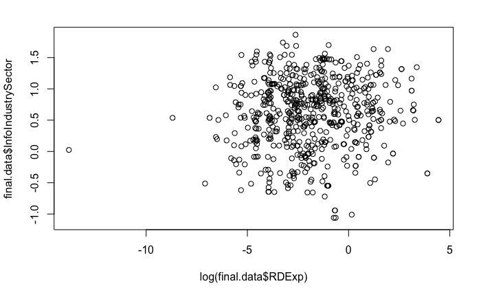

```r
plot(log(final.data$RDExp), final.data$InfoIndustrySector)
```

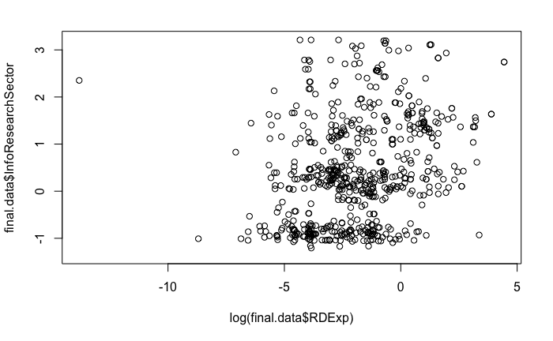

```r
plot(log(final.data$RDExp), final.data$InfoResearchSector)
```

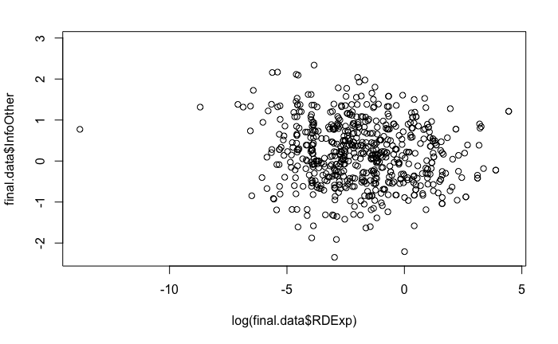

```r
plot(log(final.data$RDExp), final.data$InfoOther)
```

The Shapiro-Wilk tests below show that the factors are not normally distributed. So we must use a non-parametric test like Kendall’s Tau to test for correlation.

```r
# Factors are not normally distributed
shapiro.test(final.data$InfoIndustrySector)
```

```
    Shapiro-Wilk normality test

data:  final.data$InfoIndustrySector
W = 0.87562, p-value < 2.2e-16
```

```r
shapiro.test(final.data$InfoResearchSector)
```

```
    Shapiro-Wilk normality test

data:  final.data$InfoResearchSector
W = 0.85359, p-value < 2.2e-16
```

```r
shapiro.test(final.data$InfoOther)
```

```
    Shapiro-Wilk normality test

data:  final.data$InfoOther
W = 0.90356, p-value < 2.2e-16
```

The Kendall’s Tau test (non-parametric) rejects the null hypothesis of independence for all factors. However, the Kendall’s tau values are not large so the relationships are not strong.

```r
# tau = 1 is perfect relationship
# The null hypothesis is that there is no association between the variables under study.
cor.test(final.data$RDExp, final.data$InfoIndustrySector,  method="kendall")
```

```
    Kendall's rank correlation tau

data:  final.data$RDExp and final.data$InfoIndustrySector
z = 21.317, p-value < 2.2e-16
alternative hypothesis: true tau is not equal to 0
sample estimates:
     tau
0.417202
```

```r
cor.test(final.data$RDExp, final.data$InfoResearchSector,  method="kendall")
```

```
    Kendall's rank correlation tau

data:  final.data$RDExp and final.data$InfoResearchSector
z = 14.643, p-value < 2.2e-16
alternative hypothesis: true tau is not equal to 0
sample estimates:
      tau
0.2865897
```

```r
cor.test(final.data$RDExp, final.data$InfoOther,  method="kendall")
```

```
    Kendall's rank correlation tau

data:  final.data$RDExp and final.data$InfoOther
z = 9.1697, p-value < 2.2e-16
alternative hypothesis: true tau is not equal to 0
sample estimates:
     tau
0.179462
```